# HAR Sensors As A Predictor of Exercise Form

**BACKGROUND** Human Activity Recognition - HAR - has emerged as a key research area in the last years and is gaining increasing attention by the pervasive computing research community. Using devices such as Jawbone Up, Nike FuelBand, and Fitbit, it is now possible to collect a large amount of data about personal activity relatively inexpensively. Accelerometers were placed on the belt, forearm, arm, and dumbell of 6 study participants. They were then asked to perform barbell lifts correctly and incorrectly in 5 different ways while the accelerometer components were recorded for each.

**EXECUTIVE SUMMARY** The goal of this project is to predict the manner in which the participants did the exercise. The Random Forest model was selected and used to correctly predict the values for 20 different test cases.

**Initial Analysis** An initial look at the data in both the training and prediction data sets shows that they each contain many variables that are unrelated to the measurement of movement. The final data set will contain only data collected from the accelerometers and an outcome variable (classe).

```r
library(caret)
library(randomForest)
pml.training <- read.csv("pml-training.csv", header=TRUE)
pml.training$classe<-factor(pml.training$classe)
is.na(pml.training) <- pml.training == ''
is.na(pml.training) <- pml.training == '#DIV/0!'
train <- pml.training[,colSums(is.na(pml.training)) == 0]
train<-train[,8:60]

pml.testing <- read.csv("pml-testing.csv", header=TRUE)
is.na(pml.testing) <- pml.testing == ''
is.na(pml.testing) <- pml.testing == '#DIV/0!'
test <- pml.testing[,colSums(is.na(pml.testing)) == 0]
test<-test[,8:59]
```

Next, the training data was divided into two sets, one for training and one for internal testing.

```r
set.seed(123)
inTrain <- createDataPartition(y=train$classe,p=0.7, list=FALSE)
training <- train[inTrain,]
testing <- train[-inTrain,]
```

The expected outcome for these predictors is a categorical variable, so if we are to use a standard regression model, we will first need to encode “dummy variables” to accomodate the model. An better way is to construct a Random Forest, and make predictions with it.

```r
#trainCtrl<-trainControl(method = "cv",
#                        number=4)
#modl <- train(classe ~ ., data = training,
#             method = "rf",
#             trControl = trainCtrl)
#modl

modFit <- randomForest(classe ~., training, method = "class")
prediction<-predict(modFit,testing,type="class")
confusionMatrix(prediction, testing$classe)
```

```
## Confusion Matrix and Statistics
##
##           Reference
## Prediction    A    B    C    D    E
##          A 1673    5    0    0    0
##          B    1 1134   11    0    0
##          C    0    0 1015   15    0
##          D    0    0    0  948    0
##          E    0    0    0    1 1082
##
## Overall Statistics
##
##                Accuracy : 0.9944
##                  95% CI : (0.9921, 0.9961)
##     No Information Rate : 0.2845
##     P-Value [Acc > NIR] : < 2.2e-16
##
##                   Kappa : 0.9929
##  Mcnemar's Test P-Value : NA
##
## Statistics by Class:
##
##                      Class: A Class: B Class: C Class: D Class: E
## Sensitivity            0.9994   0.9956   0.9893   0.9834   1.0000
## Specificity            0.9988   0.9975   0.9969   1.0000   0.9998
## Pos Pred Value         0.9970   0.9895   0.9854   1.0000   0.9991
## Neg Pred Value         0.9998   0.9989   0.9977   0.9968   1.0000
## Prevalence             0.2845   0.1935   0.1743   0.1638   0.1839
## Detection Rate         0.2843   0.1927   0.1725   0.1611   0.1839
## Detection Prevalence   0.2851   0.1947   0.1750   0.1611   0.1840
## Balanced Accuracy      0.9991   0.9965   0.9931   0.9917   0.9999
```

```r
zz<-sort(modFit$importance,index=TRUE,decreasing=TRUE)
importance<-cbind(zz$x,names(training[,zz$ix]))
importance
```

```
##       [,1]               [,2]
##  [1,] "840.753858590441" "roll_belt"
##  [2,] "623.009117528011" "yaw_belt"
##  [3,] "549.794896469743" "pitch_forearm"
##  [4,] "510.510350357133" "magnet_dumbbell_z"
##  [5,] "473.994650223263" "magnet_dumbbell_y"
##  [6,] "472.634411288872" "pitch_belt"
##  [7,] "406.274813101744" "roll_forearm"
##  [8,] "339.587094906636" "magnet_dumbbell_x"
##  [9,] "306.402419614596" "accel_belt_z"
## [10,] "302.522730279951" "roll_dumbbell"
## [11,] "287.383038950061" "accel_dumbbell_y"
## [12,] "274.515023267593" "magnet_belt_y"
## [13,] "265.81805791284"  "magnet_belt_z"
## [14,] "236.638638749281" "accel_dumbbell_z"
```

[output cut: 38 more lines]

```r
nv<-c("roll_belt","yaw_belt","pitch_forearm","magnet_dumbbell_z","magnet_dumbbell_y","pitch_belt","roll_forearm","magnet_dumbbell_x","accel_belt_z","roll_dumbbell","accel_dumbbell_y","magnet_belt_y","magnet_belt_z","accel_dumbbell_z","accel_forearm_x","roll_arm","gyros_belt_z","magnet_forearm_z","magnet_arm_x","total_accel_dumbbell","gyros_dumbbell_y","yaw_dumbbell","accel_dumbbell_x","magnet_belt_x","accel_arm_x","accel_forearm_z","yaw_arm","magnet_arm_y","magnet_forearm_x","magnet_forearm_y","total_accel_belt","magnet_arm_z","pitch_arm","pitch_dumbbell","yaw_forearm","accel_arm_y","accel_forearm_y","classe")

newtraining<-subset(train,select=nv)
newtesting<-subset(testing,select=nv)
modFit <- randomForest(classe ~., newtraining, method = "class")
prediction<-predict(modFit,newtesting,type="class")
confusionMatrix(prediction, newtesting$classe)
```

```
## Confusion Matrix and Statistics
##
##           Reference
## Prediction    A    B    C    D    E
##          A 1674    0    0    0    0
##          B    0 1139    0    0    0
##          C    0    0 1026    0    0
##          D    0    0    0  964    0
##          E    0    0    0    0 1082
##
## Overall Statistics
##
##                Accuracy : 1
##                  95% CI : (0.9994, 1)
##     No Information Rate : 0.2845
##     P-Value [Acc > NIR] : < 2.2e-16
##
##                   Kappa : 1
##  Mcnemar's Test P-Value : NA
##
## Statistics by Class:
##
##                      Class: A Class: B Class: C Class: D Class: E
## Sensitivity            1.0000   1.0000   1.0000   1.0000   1.0000
## Specificity            1.0000   1.0000   1.0000   1.0000   1.0000
## Pos Pred Value         1.0000   1.0000   1.0000   1.0000   1.0000
## Neg Pred Value         1.0000   1.0000   1.0000   1.0000   1.0000
## Prevalence             0.2845   0.1935   0.1743   0.1638   0.1839
## Detection Rate         0.2845   0.1935   0.1743   0.1638   0.1839
## Detection Prevalence   0.2845   0.1935   0.1743   0.1638   0.1839
## Balanced Accuracy      1.0000   1.0000   1.0000   1.0000   1.0000
```

**PREDICTION** Utilizing the model, the outcomes of the twenty unkown test cases are predicted.

```r
unkPredict<-predict(modFit,test,type="class")
unkPredict
```

```
##  1  2  3  4  5  6  7  8  9 10 11 12 13 14 15 16 17 18 19 20
##  B  A  B  A  A  E  D  B  A  A  B  C  B  A  E  E  A  B  B  B
## Levels: A B C D E
```

*Appendix*

Plot of Actual Versus Predicted Values

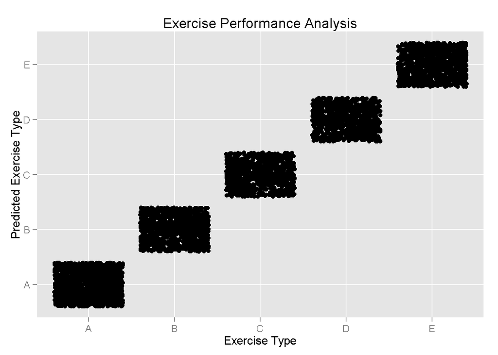

```r
testQ<-cbind(testing,prediction)
qplot(testQ$classe,testQ$prediction,geom=c("boxplot", "jitter"),  main="Exercise Performance Analysis",
xlab="Exercise Type", ylab="Predicted Exercise Type")
```

Data set obtained from: http://groupware.les.inf.puc-rio.br/static/har/dataset-har-PUC-Rio-ugulino.zip